# Predicting MIAC Baseball Game Outcomes Using Pre-Game Statistics

Ben Trutwin

2026-05-01

# 1 Introduction

## 1.1 Project Goals

Baseball is a difficult game to predict. Any given day, the worst team in the major leagues could beat the World Series Champions. It’s part of what makes the game so great. For our final project, we set out to see what variables at the division three level can be used to predict the winner of a baseball game. The goal of this project is to build a predictive model for whether the home team wins a MIAC (Minnesota Intercollegiate Athletic Conference) baseball game, using only information that would be known before the first pitch is thrown. Correctly predicting game outcomes has practical value for coaching staffs (roster and pitching deployment decisions), analysts, and fans.

This is an interesting problem for several reasons. First, small-college baseball is far less studied than professional or Division I ball, so the data may differ from what is reported in the professional analytics literature. Second, the home-field advantage at the DIII level is theoretically smaller than in professional sports, making it non-trivial to separate genuine skill signals from noise. Third, the MIAC schedule is short and weather-interrupted, meaning rolling form over the last five games could be a particularly strong predictor of present team quality.

## 1.2 Variables Used

The target variable is `home_win` — a binary indicator of whether the home team won the game (1 = Win, 0 = Loss).

Candidate predictors fall into four conceptual groups:

[output not shown]

## 1.3 How the Model Could Be Used

Given pre-game inputs (both teams’ recent form, pitching metrics, and fielding stats), the best-performing model outputs a **win probability** for the home team. A coach or analyst could use this to:

- Identify games where the model is highly confident (>75% probability) for lineup or pitching decisions.
- Track whether a team is over- or under-performing its expected win rate across a stretch of games.
- In a tournament selection context, generate an expected win total for the remainder of the regular season.

# 2 Data Source

## 2.1 Collection Method

The raw data were scraped from the MIAC Athletics website (https://miacathletics.com) using a custom R web scraper. Two complementary sources were combined:

1. **Composite schedule and box scores** — pulled from the MIAC calendar page and individual box-score pages. Each game’s date, teams, scores, result type (e.g., 7-inning doubleheader), and conference flag were captured. A total of 224 completed games from the 2026 season (February 14 through early May) were obtained.
2. **Team-level season statistics** — pitching, batting, and fielding cumulative season stats were scraped from the team statistics section of the MIAC site for each school. These were joined to the game-level data to provide season-to-date context for each team.

Rolling (last-5-game) features were engineered from the game log using a sliding window prior to each game date, ensuring no leakage of future information.

## 2.2 Reliability and Limitations

The MIAC Athletics website is the official record-keeper for the conference and is the same source used by coaches and media. Data reliability is high for completed games. However, several limitations should be noted:

- **Home season stat availability:** Home-team season-level pitching and fielding statistics exceeded 50% missing values and were dropped from the model. This likely reflects earlier-season games where season stats had not yet been populated in the database. This is an asymmetry that could bias the model toward away-team quality signals.
- **Small sample size:** After complete-case filtering, only 138 of the original 224 game rows were usable. This is a relatively small dataset for training classification models.
- **Single-season data:** All data come from the 2026 season. Year-over-year variability in team strength, roster turnover, and coaching changes is not captured.
- **No individual pitcher matchup data:** The `era_proxy_last5` is a team-level rolling proxy, not tied to a named starter. Actual day-of-game starter identity would improve predictions. We attempted to get day-of-game starter, but due to limited data and difficulty getting a consistent match in our models, we omitted same day starter.
- **Strength of schedule:** There was no way to measure the quality of opponents in this dataset. In the introduction, we mentioned that any baseball team at the professional level could win against anybody. This is not the case in division three baseball, as the talent gap ranges heavily. Some teams have players that will get drafted to MLB teams, while others have players that wouldn’t play on some high school teams. A team that plays very little competition all year would likely have amazing stats compared to a team in a strong conference, and would be favored in a head-to-head matchup, even if there is a large talent gap for the team facing strong competition.

# 3 Exploratory Analysis

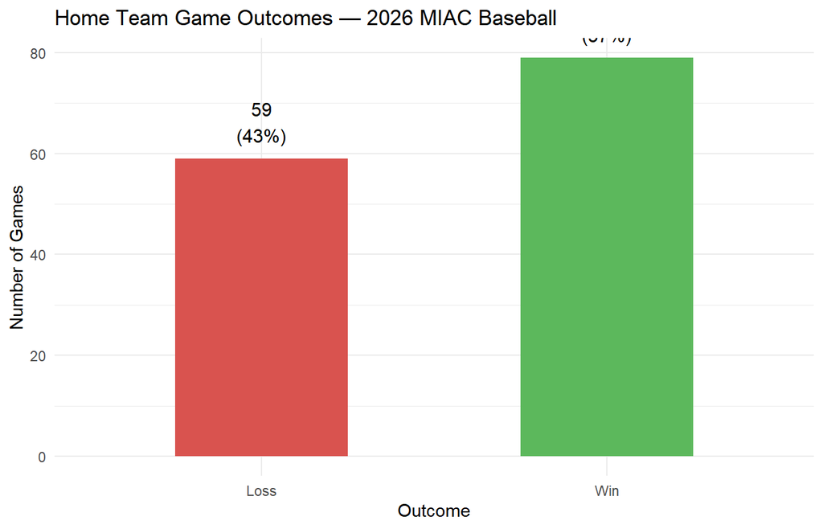

Distribution of the target variable. The home team won 57% of completed games, showing a modest home-field advantage.

The home team won 79 of 138 modeled games (57%), reflecting a modest but meaningful home-field advantage. This moderate class imbalance means a naive baseline classifier that always predicts “Win” would achieve only 57% accuracy, so model accuracy needs to be evaluated against this baseline.

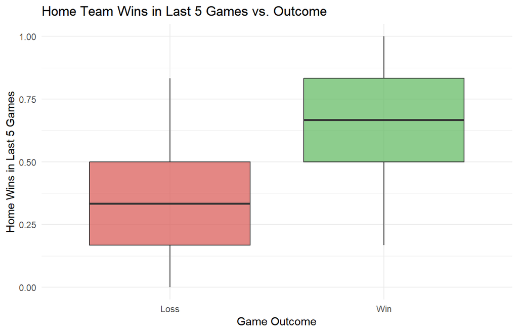

Home team recent wins (last 5 games) split by outcome. Teams with more recent wins are more likely to win at home.

The boxplot above shows a clear separation between wins and losses based on the home team’s recent form. Home teams that go on to win have a noticeably higher median win count in their last five games compared to those that lose. This aligns with the LASSO model’s finding that `home_win_last5` was the single most important predictor — recent momentum is a meaningful signal in short-season DIII baseball.

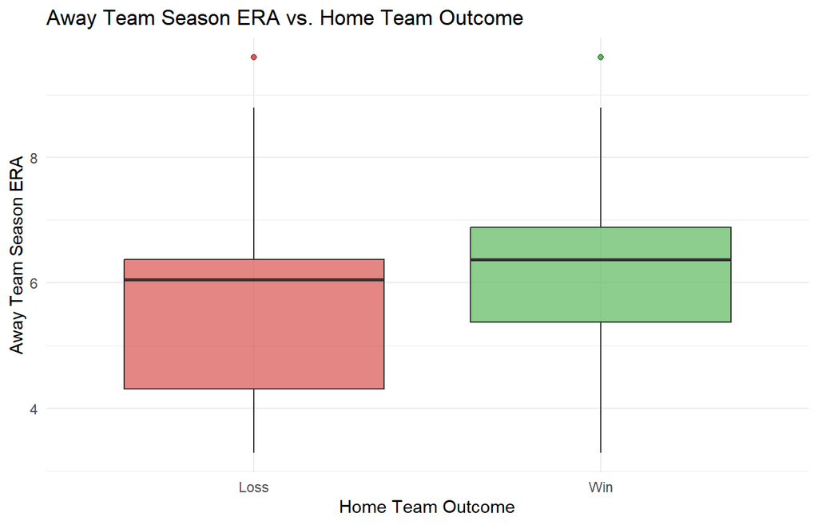

Away team season ERA split by home team outcome. Lower away ERA (better pitching) is associated with the home team losing.

There is only a modest difference in away team ERA between home wins and losses, indicating that season-long pitching quality for the away team is not a major driver of single-game outcomes in this context. Other factors, such as recent team performance or short-term momentum, may be more predictive. One of the reasons for this might be that the MIAC has traditionally been an offensive league, with most games being high scoring. There also might be a lot of unearned runs, which won’t affect ERA, but would affect the game outcome. Unearned runs were not a statistic on the MIAC website.

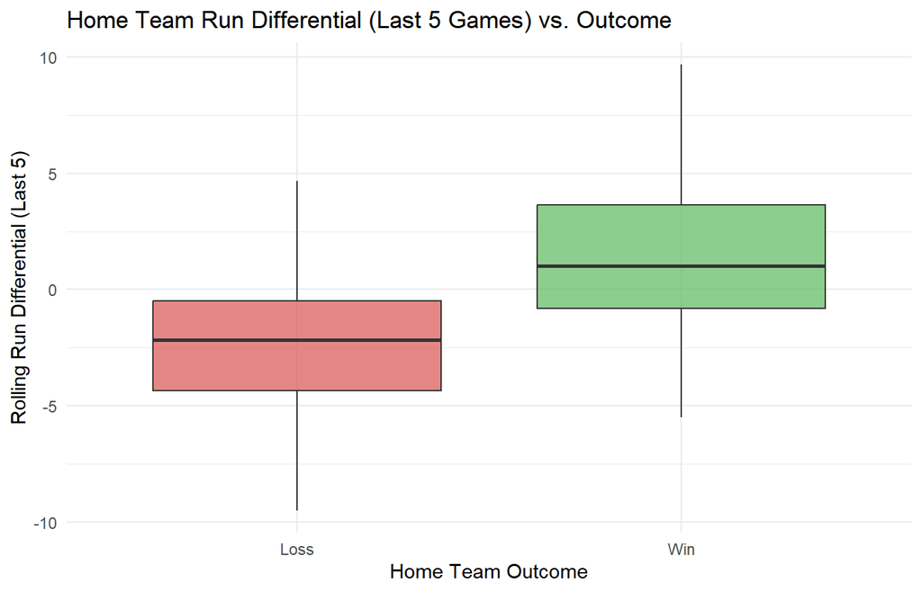

Home team rolling run differential (last 5 games) by outcome.

Teams with a positive recent run differential are much more likely to win their next home game, while those with a negative differential are more likely to lose. This variable captures short-term team performance and is a valuable predictor in the model.

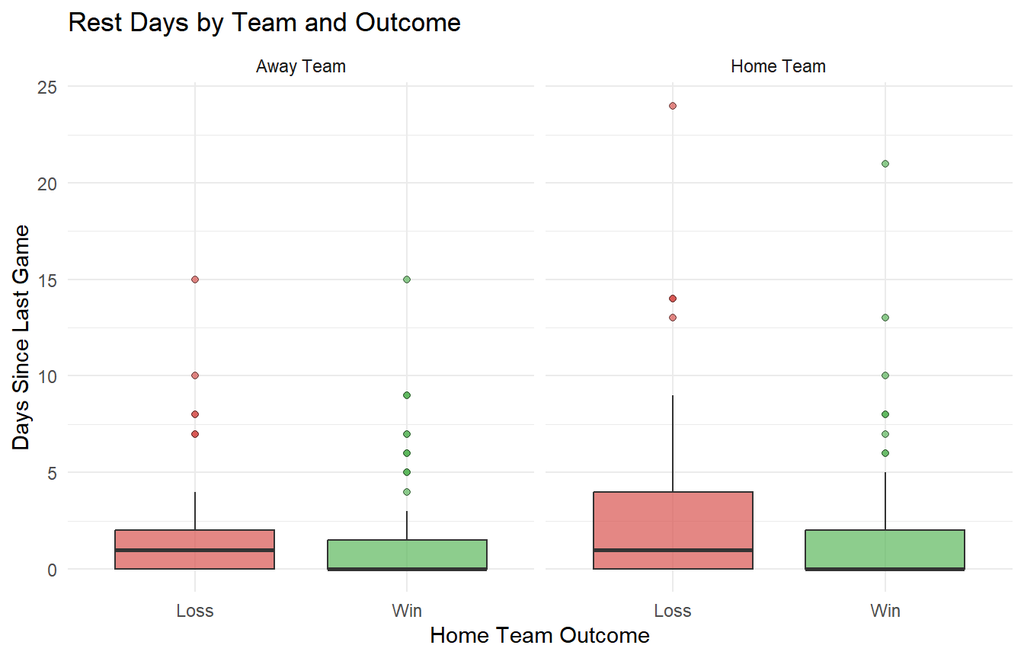

Rest days for home and away teams by game outcome.

Rest days do not appear to have a strong or systematic effect on game outcomes in this dataset. Both winners and losers tend to have similar rest patterns, and any differences are minor compared to the overall spread and overlap. This suggests that, at least in this MIAC season, rest was not a decisive factor in determining which team won.

# 4 Modeling

## 4.1 Design Decisions

**Feature selection philosophy:** Only features available *before* the game were included. Outcome variables (final score, run differential, winner) were explicitly excluded to prevent data leakage. The 10 home-team season-level statistics that were more than 50% missing were dropped rather than imputed, as imputing over half of a column introduces more noise than signal.

**Train/test split:** An 80/20 random split (110 train, 28 test) was used. Given the small dataset, a fixed seed (42) was set for reproducibility. Cross-validation was additionally used within the LASSO model for hyperparameter tuning.

**Three model types were fit:**

1. **Logistic Regression** — A full-feature baseline. Interpretable and appropriate for binary classification, but susceptible to overfitting with 26 predictors and only 110 training observations.
2. **LASSO (Regularized Logistic Regression)** — Uses an L1 penalty to shrink less important coefficients to zero, performing automatic feature selection. The penalty parameter $\lambda$ was chosen by 10-fold cross-validation using the one-standard-error rule for parsimony.
3. **Random Forest** — An ensemble of 500 decision trees using $\sqrt{p} \approx 5$ variables per split. Well-suited to capturing non-linear interactions between predictors, but less interpretable than logistic approaches.

Best Subset Selection (BeSS) was also attempted but the R implementation returned a degenerate solution (zero selected variables, zero test predictions), likely due to the small sample size and the binary outcome structure. It was excluded from the final comparison.

## 4.2 LASSO: Feature Selection

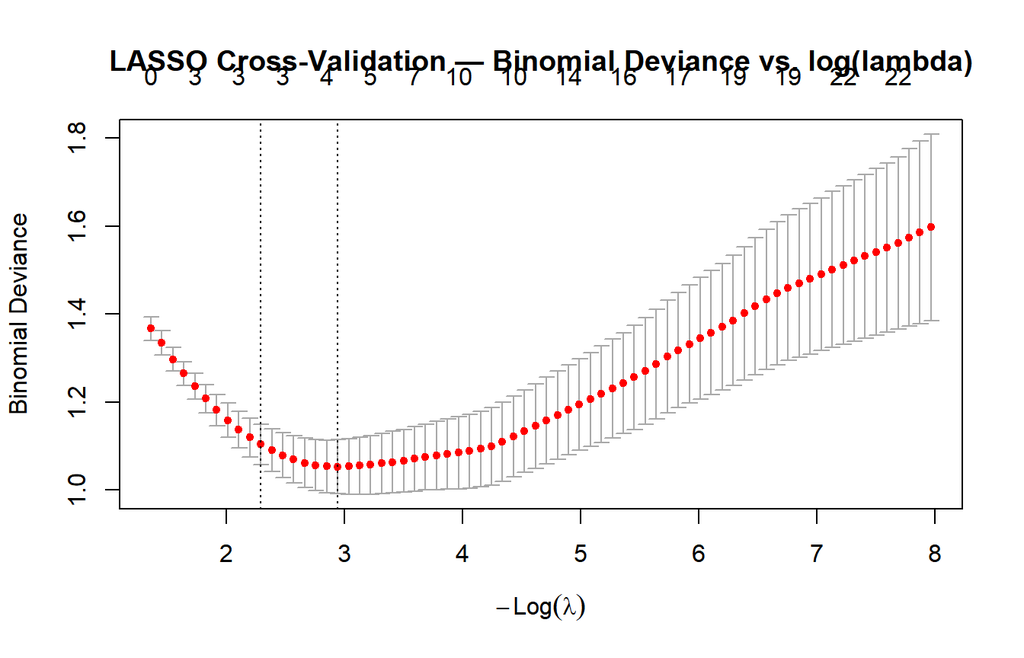

10-fold cross-validation curve for LASSO. The dotted lines mark the minimum-deviance lambda and the 1-SE rule lambda used in this analysis.

- `home_win_last5` — Home team’s wins in its last 5 games
- `away_win_last5` — Away team’s wins in its last 5 games
- `away_rd_last5` — Away team’s rolling run differential over the last 5 games

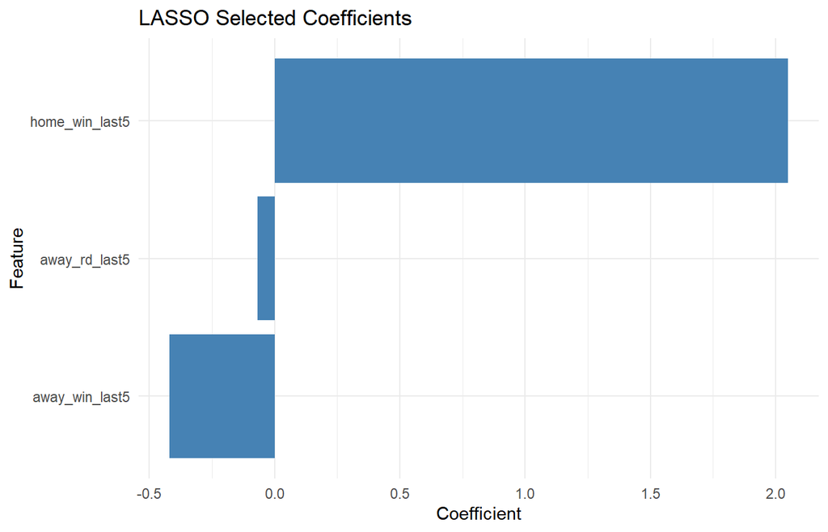

Non-zero LASSO coefficients at the 1-SE lambda. Positive values increase the probability of a home win; negative values decrease it.

The coefficient plot reinforces the narrative from the EDA: recent winning form for the home team positively predicts a home win, while a strong recent run differential for the away team reduces the home team’s chances. The model’s signal is concentrated in short-term momentum, not season-long aggregate statistics.

## 4.3 Random Forest: Variable Importance

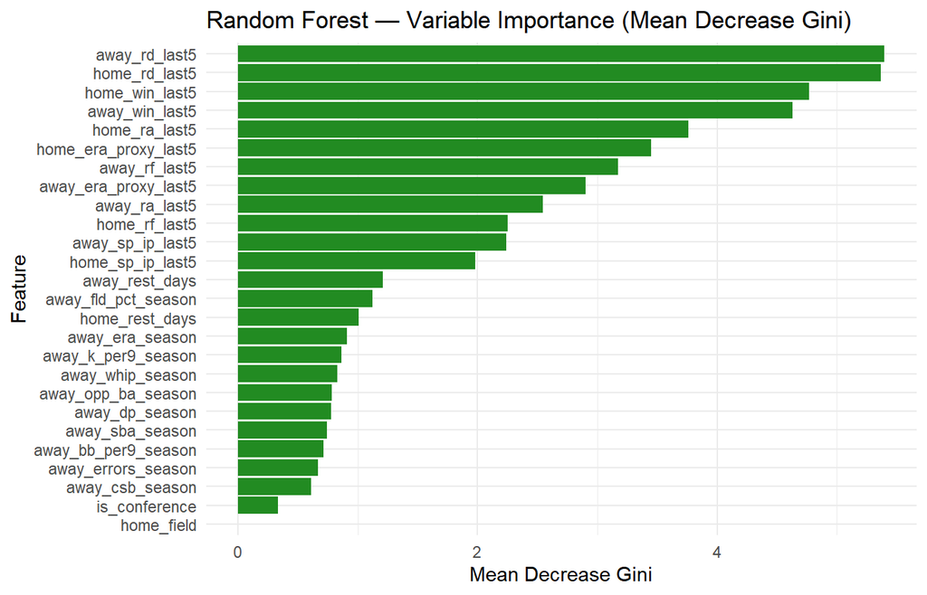

Random Forest variable importance ranked by Mean Decrease in Gini impurity. Higher values indicate features that more effectively split observations into correct classes.

The Random Forest model relies most heavily on recent team performance (especially run differential and win count over the last 5 games) to predict game outcomes. Season-long stats and game context play a much smaller role. This reinforces the finding that short-term momentum is the strongest signal in this dataset.

## 4.4 Model Performance Comparison

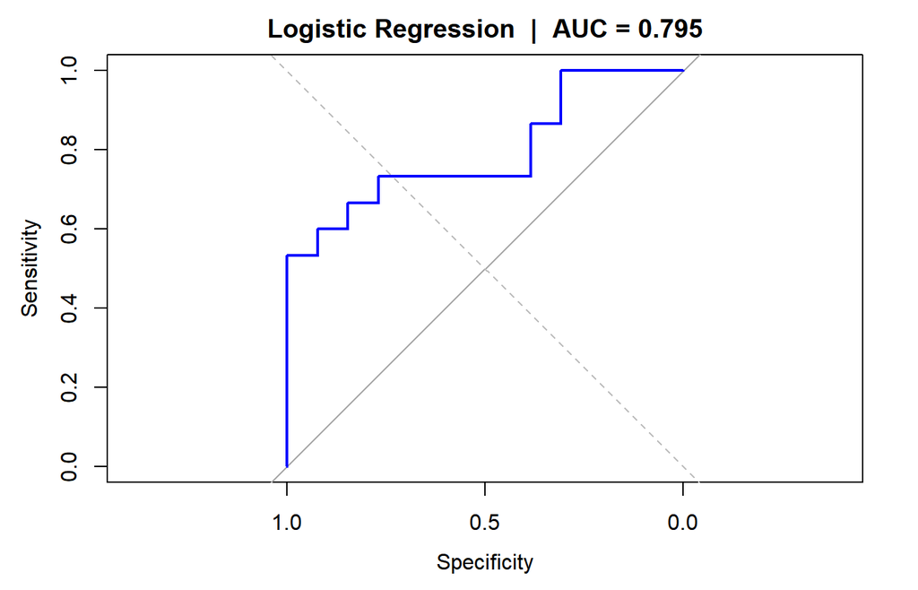

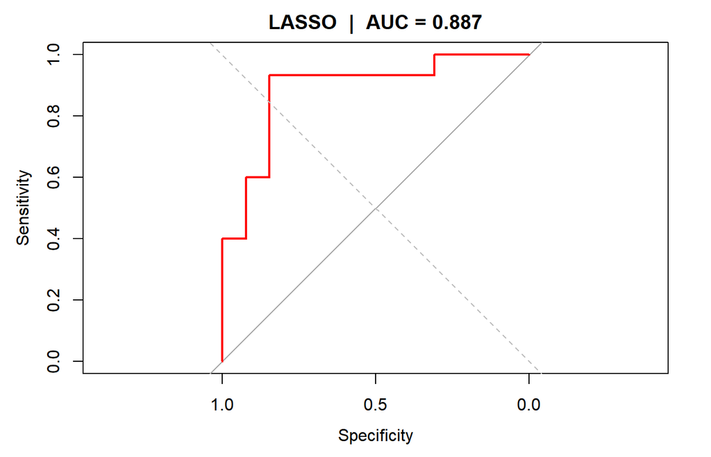

ROC curve for LASSO on the held-out test set.

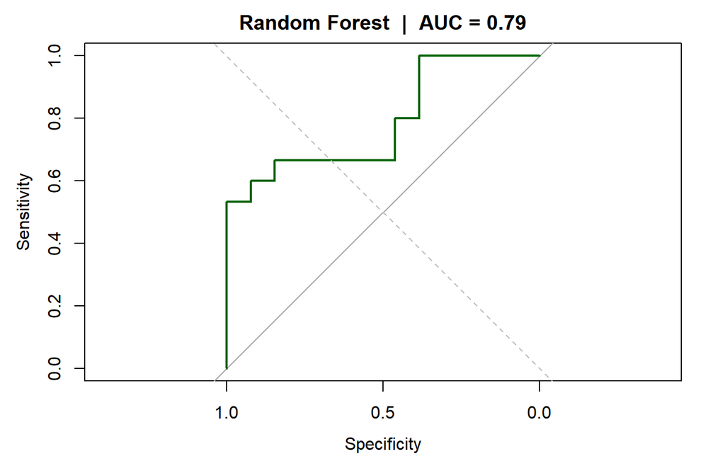

ROC curve for Random Forest on the held-out test set.

Test-Set Performance Summary

| Model | Accuracy | AUC | Sensitivity | Specificity |
| --- | --- | --- | --- | --- |
| Logistic Regression | 0.7500 | 0.7949 | 0.7333 | 0.7692 |
| LASSO | 0.8571 | 0.8872 | 0.8667 | 0.8462 |
| Random Forest | 0.6429 | 0.7897 | 0.6667 | 0.6154 |

LASSO outperformed both other models on every metric, achieving 85.7% accuracy and an AUC of 0.887, remarkable for a model using only three predictors. The full logistic regression, despite using all 26 available features, achieved lower accuracy (75%) and lower AUC (0.795). This strongly suggests the full model is overfitting on the 110-observation training set. The Random Forest performed worst on accuracy (64.3%) despite a reasonable AUC (0.790), likely due to the very small test set (28 games) and the inherent variance of ensemble methods at this sample size.

## 4.5 Error Tradeoffs

In this context, there are two types of prediction errors:

- **False Positive (predicting Win when the home team loses):** Would lead a coach or analyst to over-rate the home team’s chances and potentially deploy resources (e.g., a top starter) on a game where the team was not actually favored.
- **False Negative (predicting Loss when the home team wins):** Would cause an analyst to underestimate the home team’s chances and potentially under-prepare.

## 4.6 Possible Enhancements

Several enhancements could meaningfully improve model performance:

1. **Multi-season data:** Training on 2023–2026 data would increase sample size from ~138 to potentially 500+ observations, stabilizing all three models and enabling more reliable evaluation.
2. **Named starter identity:** Adding the actual starting pitcher’s season ERA/WHIP (rather than a team-level proxy) would capture the single most important pre-game signal in baseball. We tried for awhile, but couldn’t get a consistent match in data, so we chose to emit the data with how small the sample size was.
3. **Head-to-head history:** Recent series results between the same two teams may carry additional signal not captured by aggregate rolling stats. Knowing schools history like potential rivalries may also influence how schools play against each other.
4. **Weather/field conditions:** Temperature and wind are known to affect scoring in baseball but are not currently included.
5. **Home season stats recovery:** Resolving the data availability gap that caused home season-level pitching and fielding stats to be dropped would allow a more symmetric model.

# 5 Beyond Wins: What Performance Metrics Drive Game Outcomes?

The LASSO model’s best predictors – recent win percentage for both teams — are informative but somewhat circular: teams that win a lot tend to keep winning. A more actionable question is: which performance-based metrics (runs, ERA, run differential, pitching quality) predict game outcomes independent of win rate? This section re-fits a LASSO model after completely removing all win-count features, forcing the model to rely on the underlying production stats that actually *drive* wins.

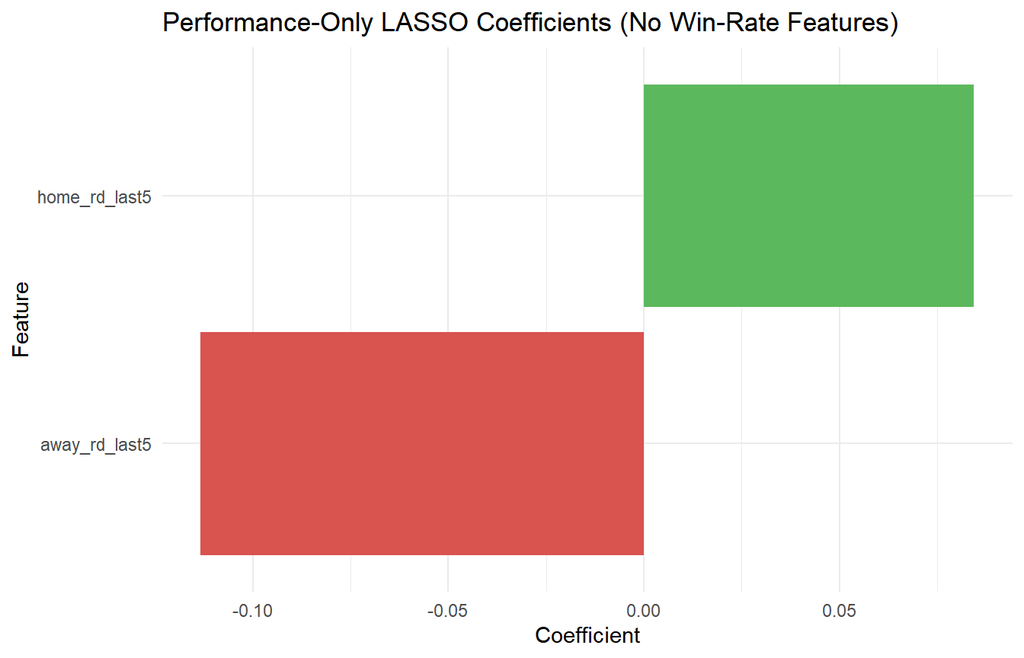

Non-zero LASSO coefficients when win-count features are excluded. Only performance-based metrics compete for selection.

LASSO With vs. Without Win-Rate Features

| Model | Accuracy | AUC | Sensitivity | Specificity |
| --- | --- | --- | --- | --- |
| LASSO (all features) | 0.8571 | 0.8872 | 0.8667 | 0.8462 |
| LASSO (no win-rate features) | 0.7500 | 0.8615 | 0.9333 | 0.5385 |

Removing win-rate features expectedly reduces performance somewhat, but the performance-only model still achieves meaningful predictive power, demonstrating that underlying production stats carry genuine signal beyond momentum. The comparison above quantifies how much of the original LASSO’s edge came from win rate versus true performance metrics.

## 5.1 Top 2 Performance Predictors

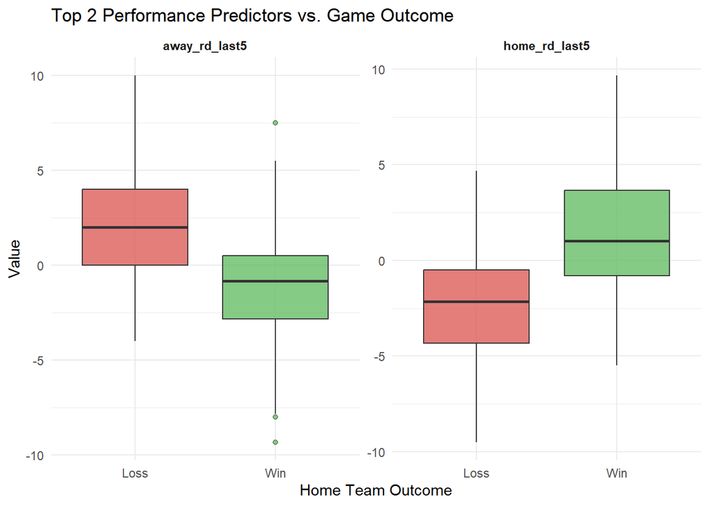

Distributions of the top 2 performance-based predictors split by game outcome. These are the variables that matter most once win rate is removed from consideration.

## 5.2 Partial Effect: How Each Predictor Shifts Win Probability

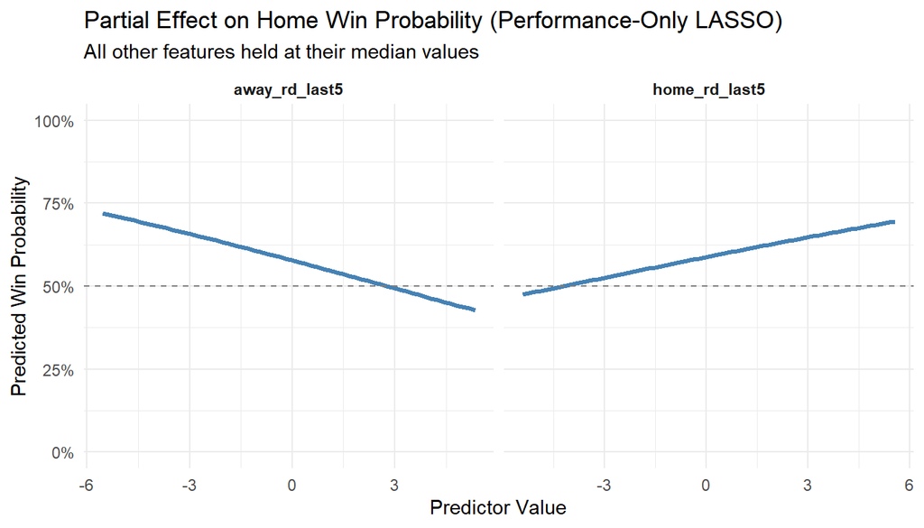

The partial effect plots above isolate each predictor’s contribution, holding everything else equal. A steeper slope indicates a predictor with stronger marginal influence on win probability. The dashed line marks the 50% threshold. Values above push the model toward a predicted home win, values below toward a predicted loss.

# 6 Conclusion

This project demonstrated that MIAC baseball game outcomes can be predicted at a meaningfully above-chance level using publicly available pre-game statistics. The LASSO model, despite retaining only three features: home team wins in the last 5 games, away team wins in the last 5 games, and away team run differential over the last 5 games, achieved 85.7% test-set accuracy and an AUC of 0.887. This suggests that in short-season DIII baseball, recent form is far more predictive than long-run season averages, at least at the sample sizes available.

The full logistic regression and random forest both underperformed LASSO on this small dataset, consistent with the well-known bias-variance tradeoff: simpler, regularized models outperform complex ones when training data is limited. The primary constraint on this project is sample size, and the most impactful future improvement would be expanding the dataset to multiple seasons.

# 7 References

MIAC Athletics. (2026). *2026 MIAC Baseball Schedule, Scores, and Statistics*. Minnesota Intercollegiate Athletic Conference. Retrieved from https://miacathletics.com/calendar.aspx?path=baseball. Data compiled via custom R web scraper, April 2026.